# Homework 1_a

Mohsen Nabian

9/28/2015

## Homework Question 1

*Probability distributions*

- Replicate and plot the fat-tailed Cauchy distributions from https://en.wikipedia.org/wiki/Cauchy_distribution
- Load the file M01_Lesson_02_Q1.csv
- Answer the following questions for the data in each column:
  - How is the data distributed?
  - What are the summary statistics?
  - Are there anomalies/outliers?
  - Try to regenerate the data in each column.
  - Plot your regenerated data versus the original data using a faceted graph. How does it compare?

```r
# Drawing the Cauchy Distribution
#install.packages('ggplot2')
require(ggplot2)
##############
```

```r
cauchy<-data.frame(A=rcauchy(100000,0,0.5),B=rcauchy(100000,0,1),
                   C=rcauchy(100000,0,2),D=rcauchy(100000,-2,1))

require(reshape2)
rnd <- melt(data=cauchy)    #Changing the form of data frame
head(rnd)
```

```
##   variable      value
## 1        A -0.5101977
## 2        A -4.3953980
## 3        A -1.3207292
## 4        A -0.2363928
## 5        A  0.3766401
## 6        A -1.9911751
```

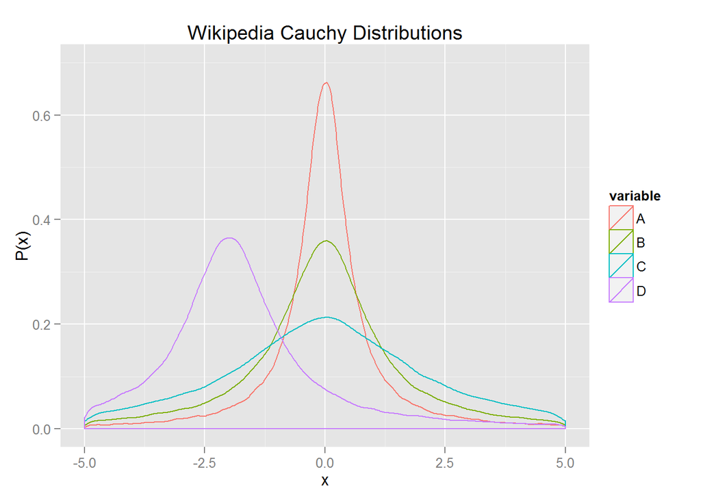

```r
g<-ggplot(data=rnd)+ aes(x=value)+aes(group=variable)+aes(color=variable)
g<-g+geom_density()
g<-g+xlim(-5,5)+ylim(0,0.7)
g<-g+labs(title="Wikipedia Cauchy Distributions", y="P(x)", x="x")
g
```

```r
#####################################################
```

```r
DATA<-read.csv("C:/Users/nabian.m/OneDrive/Fall 2015/intr. Data mining and Machine learning/Week1/HomeWork/M01_Lesson_02_Q1.csv",header=TRUE)
head(DATA)
```

```
##   X         A          B C  D         E
## 1 1  8.257164 -0.6560755 6  8 309.67242
## 2 2 10.557378 -0.7158294 7  8 301.74808
## 3 3  8.744211  0.7996107 7  5 158.75132
## 4 4  6.555028  1.5832173 6 10 293.42639
## 5 5  9.362121  1.0272024 7  8 261.03700
## 6 6  9.020671  0.7197130 7 12  80.01178
```

## Column A

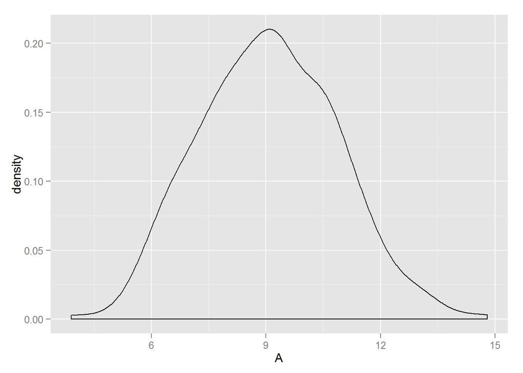

```r
#Column A

g0<-ggplot(data=DATA)
g1<-g0+aes(x=A)+geom_density()
g1
```

```r
vect<-DATA$A
summary(vect)
```

```
##    Min. 1st Qu.  Median    Mean 3rd Qu.    Max.
##   3.902   7.793   9.072   9.079  10.390  14.790
```

based on the shape of the distribution and the fact that mean and median are very close, the distribution is very similar to a gussian distribution.

```r
lowerq = quantile(vect)[2]
upperq = quantile(vect)[4]
innerq = upperq - lowerq #Or use IQR(data)
threshold.upper = (innerq * 1.5) + upperq
threshold.lower = lowerq - (innerq * 1.5)
outlier<-sum((vect>threshold.upper))+sum((vect<threshold.lower))
outlier
```

```
## [1] 1
```

```r
##############################
```

So there is only 1 outlier here based on this definition that we coded.

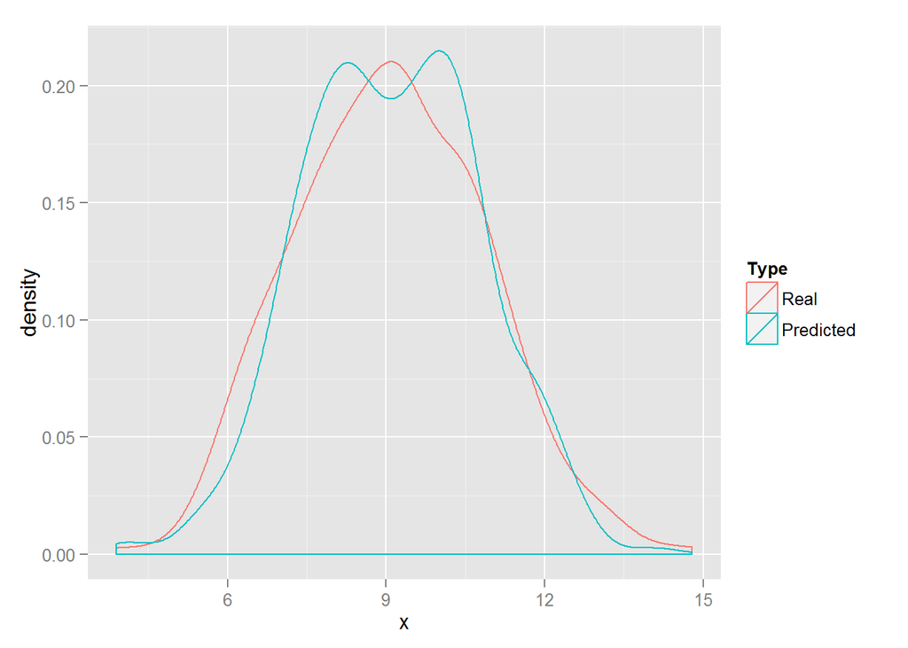

```r
miu<-mean(DATA$A)
sdd<-sd(DATA$A)
my_A<-rnorm(length(DATA$A),miu,sdd)
df<-data.frame(x=DATA$A,Type=as.factor('Real'))
df<-rbind(df,data.frame(x=my_A,Type=as.factor('Predicted')))

g0<-ggplot(data=df)+aes(x=x,color=Type)+geom_density()
g0
```

## Column B

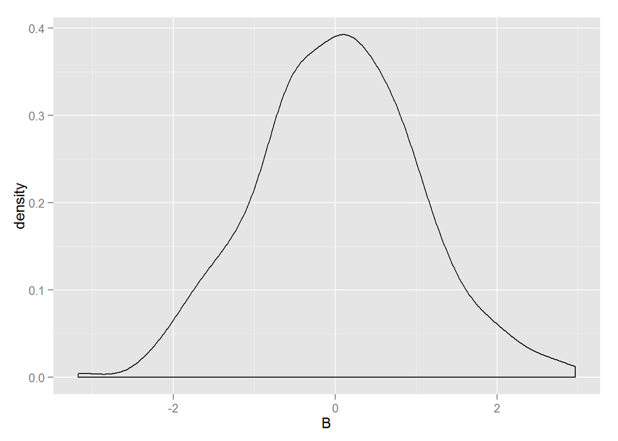

```r
#Column B

g0<-ggplot(data=DATA)
g2<-g0+aes(x=B)+geom_density()
g2
```

```r
vect<-DATA$B
summary(vect)
```

```
##     Min.  1st Qu.   Median     Mean  3rd Qu.     Max.
## -3.17600 -0.63200  0.03412  0.03063  0.67030  2.96900
```

This is also close to the normal distribution due to the shape as well as the fact that median and mean are very close. However, a handful of outliers are visually detectable from the distribution.

```r
lowerq = quantile(vect)[2]
upperq = quantile(vect)[4]
innerq = upperq - lowerq #Or use IQR(data)
threshold.upper = (innerq * 1.5) + upperq
threshold.lower = lowerq - (innerq * 1.5)
outlier<-sum((vect>threshold.upper))+sum((vect<threshold.lower))
outlier
```

```
## [1] 3
```

```r
##############################
```

So there are 3 outliers here based on this definition that we coded.

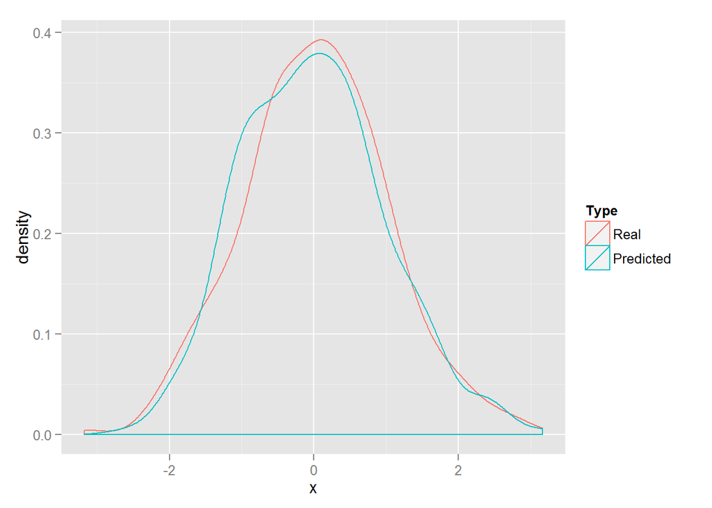

```r
miu<-mean(DATA$B)
sdd<-sd(DATA$B)
my_B<-rnorm(length(DATA$B),miu,sdd)
df<-data.frame(x=DATA$B,Type=as.factor('Real'))
df<-rbind(df,data.frame(x=my_B,Type=as.factor('Predicted')))

g0<-ggplot(data=df)+aes(x=x,color=Type)+geom_density()
g0
```

## Column C

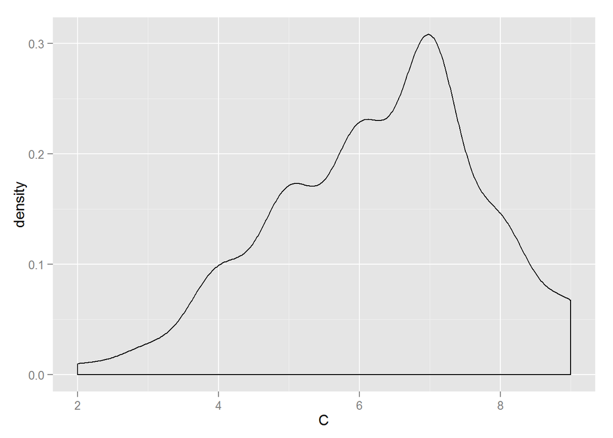

```r
#Column C

g0<-ggplot(data=DATA)
g3<-g0+aes(x=C)+geom_density()
g3
```

```r
vect<-DATA$C
summary(vect)
```

```
##    Min. 1st Qu.  Median    Mean 3rd Qu.    Max.
##     2.0     5.0     6.0     6.3     7.0     9.0
```

```r
lowerq = quantile(vect)[2]
upperq = quantile(vect)[4]
innerq = upperq - lowerq #Or use IQR(data)
threshold.upper = (innerq * 1.5) + upperq
threshold.lower = lowerq - (innerq * 1.5)
outlier<-sum((vect>threshold.upper))+sum((vect<threshold.lower))
outlier
```

```
## [1] 0
```

```r
###############################
```

Based on the outlier definition that is coded, there is no outlier.

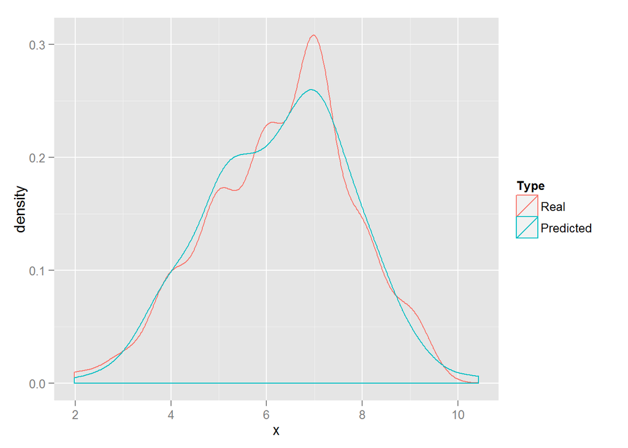

```r
miu<-mean(DATA$C)
sdd<-sd(DATA$C)
my_C<-rnorm(length(DATA$C),miu,sdd)
df<-data.frame(x=DATA$C,Type=as.factor('Real'))
df<-rbind(df,data.frame(x=my_C,Type=as.factor('Predicted')))

g0<-ggplot(data=df)+aes(x=x,color=Type)+geom_density()
g0
```

## Column D

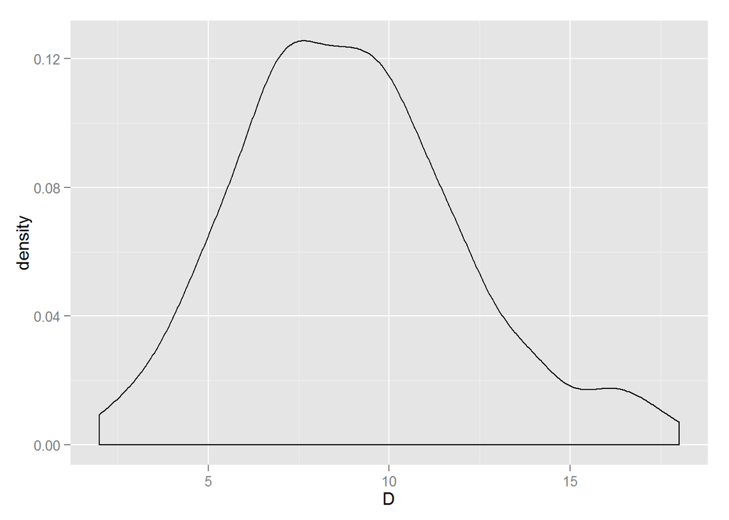

```r
#Column D

g0<-ggplot(data=DATA)
g4<-g0+aes(x=D)+geom_density()
g4
```

```r
vect<-DATA$D
summary(vect)
```

```
##    Min. 1st Qu.  Median    Mean 3rd Qu.    Max.
##   2.000   7.000   9.000   8.919  11.000  18.000
```

The mean and median are very close an d the distribution look like a normal distribution. However, we might have a few outliers.

```r
lowerq = quantile(vect)[2]
upperq = quantile(vect)[4]
innerq = upperq - lowerq #Or use IQR(data)
threshold.upper = (innerq * 1.5) + upperq
threshold.lower = lowerq - (innerq * 1.5)
outlier<-sum((vect>threshold.upper))+sum((vect<threshold.lower))
outlier
```

```
## [1] 2
```

```r
###############################
```

we have 2 outliers based on the definition.

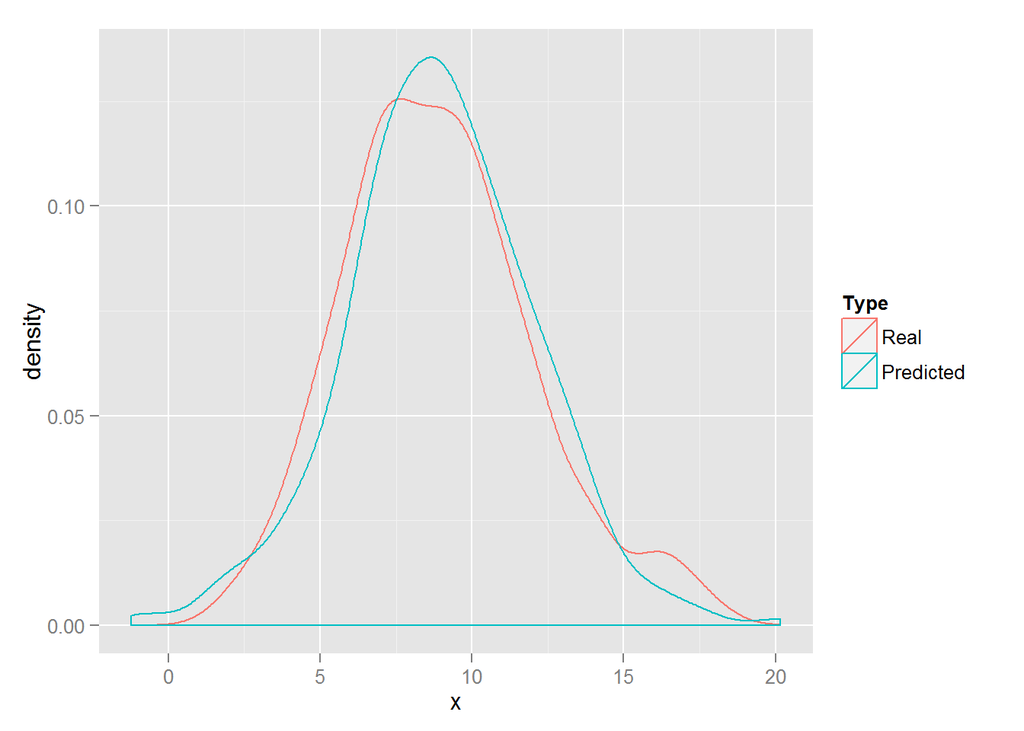

```r
miu<-mean(DATA$D)
sdd<-sd(DATA$D)
my_D<-rnorm(length(DATA$D),miu,sdd)
df<-data.frame(x=DATA$D,Type=as.factor('Real'))
df<-rbind(df,data.frame(x=my_D,Type=as.factor('Predicted')))

g0<-ggplot(data=df)+aes(x=x,color=Type)+geom_density()
g0
```

## Column E

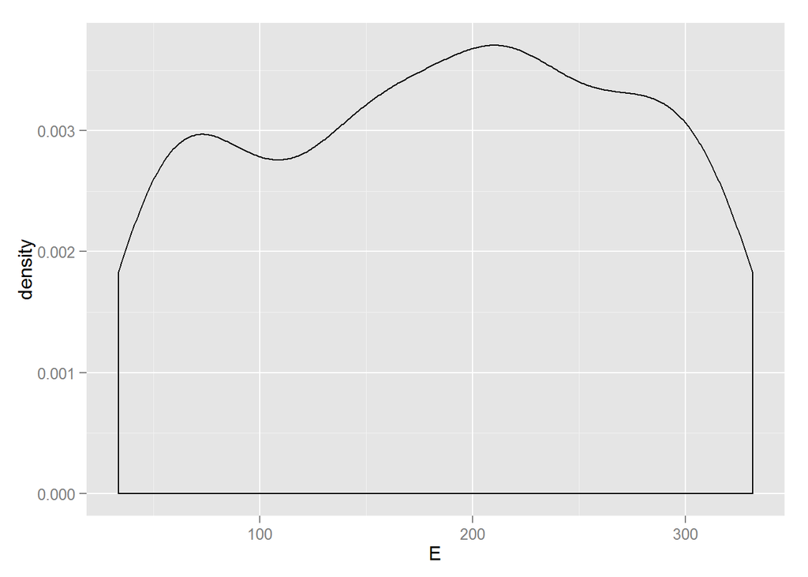

```r
#Column E

g0<-ggplot(data=DATA)
g5<-g0+aes(x=E)+geom_density()
g5
```

```r
vect<-DATA$E
summary(vect)
```

```
##    Min. 1st Qu.  Median    Mean 3rd Qu.    Max.
##   33.52  112.30  194.10  185.90  258.40  331.80
```

Here the distribution is close to a uniform distribution.

```r
lowerq = quantile(vect)[2]
upperq = quantile(vect)[4]
innerq = upperq - lowerq #Or use IQR(data)
threshold.upper = (innerq * 1.5) + upperq
threshold.lower = lowerq - (innerq * 1.5)
outlier<-sum((vect>threshold.upper))+sum((vect<threshold.lower))
outlier
```

```
## [1] 0
```

```r
###############################
```

No outlier found.

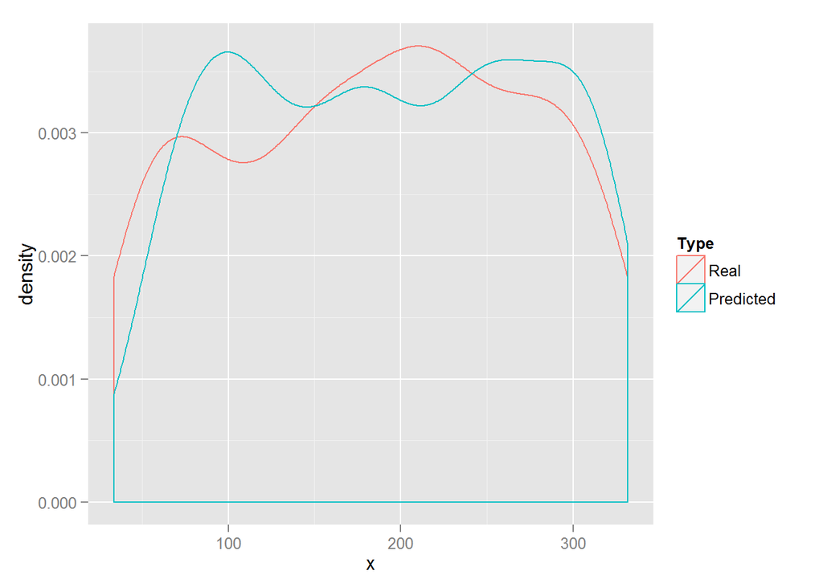

```r
miu<-mean(DATA$E)

my_E<-runif(length(DATA$E),50,330)
df<-data.frame(x=DATA$E,Type=as.factor('Real'))
df<-rbind(df,data.frame(x=my_E,Type=as.factor('Predicted')))

g0<-ggplot(data=df)+aes(x=x,color=Type)+geom_density()
g0
```